# AML Assignment

Justin Ng

9/26/2022

# LOADING DATASET & LIBRARIES

Reading Excel dataset

```r
library(readxl)
dataset <- read_excel("E Commerce Dataset.xlsx",
    sheet = "E Comm")
View(dataset)
```

Loading the necessary libraries

```r
library(tidyverse) # master library set
library(DataExplorer) #EDA
library(mice) # build in imputation model (use regression for imputation)
library(ROSE) # balancing data
library(caTools) # stratified sampling - splitting the dataset
library(caret) # classification & regression training
```

```r
library(ROCR) # plot ROC curve
library(ggplot2) # plot visualizations
library(e1071) # to build SVM models
library(rpart) #to build Decision Trees
library(rpart.plot) #to plot Decision Trees
```

# INITIAL DATA EXPLORATION

Exploring dataset structure and summary statistic

```r
introduce(dataset)
```

```
## # A tibble: 1 x 9
##    rows columns discrete_columns conti~1 all_m~2 total~3 compl~4 total~5 memor~6
##   <int>   <int>            <int>   <int>   <int>   <int>   <int>   <int>   <dbl>
## 1  5630      20                5      15       0    1856    3774  112600  907224
## # ... with abbreviated variable names 1: continuous_columns,
## #   2: all_missing_columns, 3: total_missing_values, 4: complete_rows,
## #   5: total_observations, 6: memory_usage
```

```r
str(dataset)
```

```
## tibble [5,630 x 20] (S3: tbl_df/tbl/data.frame)
##  $ CustomerID                 : num [1:5630] 50001 50002 50003 50004 50005 ...
##  $ Churn                      : num [1:5630] 1 1 1 1 1 1 1 1 1 1 ...
##  $ Tenure                     : num [1:5630] 4 NA NA 0 0 0 NA NA 13 NA ...
##  $ PreferredLoginDevice       : chr [1:5630] "Mobile Phone" "Phone" "Phone" "Phone" ...
##  $ CityTier                   : num [1:5630] 3 1 1 3 1 1 3 1 3 1 ...
##  $ WarehouseToHome            : num [1:5630] 6 8 30 15 12 22 11 6 9 31 ...
##  $ PreferredPaymentMode       : chr [1:5630] "Debit Card" "UPI" "Debit Card" "Debit Card" ...
##  $ Gender                     : chr [1:5630] "Female" "Male" "Male" "Male" ...
##  $ HourSpendOnApp             : num [1:5630] 3 3 2 2 NA 3 2 3 NA 2 ...
##  $ NumberOfDeviceRegistered   : num [1:5630] 3 4 4 4 3 5 3 3 4 5 ...
##  $ PreferedOrderCat           : chr [1:5630] "Laptop & Accessory" "Mobile" "Mobile" "Laptop & Accessory" ...
##  $ SatisfactionScore          : num [1:5630] 2 3 3 5 5 5 2 2 3 3 ...
##  $ MaritalStatus              : chr [1:5630] "Single" "Single" "Single" "Single" ...
##  $ NumberOfAddress            : num [1:5630] 9 7 6 8 3 2 4 3 2 2 ...
##  $ Complain                   : num [1:5630] 1 1 1 0 0 1 0 1 1 0 ...
##  $ OrderAmountHikeFromlastYear: num [1:5630] 11 15 14 23 11 22 14 16 14 12 ...
##  $ CouponUsed                 : num [1:5630] 1 0 0 0 0 4 0 2 0 1 ...
##  $ OrderCount                 : num [1:5630] 1 1 1 1 1 6 1 2 1 1 ...
##  $ DaySinceLastOrder          : num [1:5630] 5 0 3 3 3 7 0 0 2 1 ...
##  $ CashbackAmount             : num [1:5630] 160 121 120 134 130 ...
```

```r
summary(dataset)
```

```
##    CustomerID        Churn            Tenure      PreferredLoginDevice
##  Min.   :50001   Min.   :0.0000   Min.   : 0.00   Length:5630
##  1st Qu.:51408   1st Qu.:0.0000   1st Qu.: 2.00   Class :character
##  Median :52816   Median :0.0000   Median : 9.00   Mode  :character
##  Mean   :52816   Mean   :0.1684   Mean   :10.19
##  3rd Qu.:54223   3rd Qu.:0.0000   3rd Qu.:16.00
##  Max.   :55630   Max.   :1.0000   Max.   :61.00
##                                   NA's   :264
##     CityTier     WarehouseToHome  PreferredPaymentMode    Gender
##  Min.   :1.000   Min.   :  5.00   Length:5630          Length:5630
##  1st Qu.:1.000   1st Qu.:  9.00   Class :character     Class :character
##  Median :1.000   Median : 14.00   Mode  :character     Mode  :character
##  Mean   :1.655   Mean   : 15.64
##  3rd Qu.:3.000   3rd Qu.: 20.00
##  Max.   :3.000   Max.   :127.00
##                  NA's   :251
##  HourSpendOnApp  NumberOfDeviceRegistered PreferedOrderCat   SatisfactionScore
##  Min.   :0.000   Min.   :1.000            Length:5630        Min.   :1.000
##  1st Qu.:2.000   1st Qu.:3.000            Class :character   1st Qu.:2.000
##  Median :3.000   Median :4.000            Mode  :character   Median :3.000
##  Mean   :2.932   Mean   :3.689                               Mean   :3.067
##  3rd Qu.:3.000   3rd Qu.:4.000                               3rd Qu.:4.000
##  Max.   :5.000   Max.   :6.000                               Max.   :5.000
##  NA's   :255
##  MaritalStatus      NumberOfAddress     Complain
##  Length:5630        Min.   : 1.000   Min.   :0.0000
##  Class :character   1st Qu.: 2.000   1st Qu.:0.0000
##  Mode  :character   Median : 3.000   Median :0.0000
##                     Mean   : 4.214   Mean   :0.2849
##                     3rd Qu.: 6.000   3rd Qu.:1.0000
##                     Max.   :22.000   Max.   :1.0000
##
##  OrderAmountHikeFromlastYear   CouponUsed       OrderCount
##  Min.   :11.00               Min.   : 0.000   Min.   : 1.000
##  1st Qu.:13.00               1st Qu.: 1.000   1st Qu.: 1.000
##  Median :15.00               Median : 1.000   Median : 2.000
##  Mean   :15.71               Mean   : 1.751   Mean   : 3.008
##  3rd Qu.:18.00               3rd Qu.: 2.000   3rd Qu.: 3.000
##  Max.   :26.00               Max.   :16.000   Max.   :16.000
##  NA's   :265                 NA's   :256      NA's   :258
##  DaySinceLastOrder CashbackAmount
##  Min.   : 0.000    Min.   :  0.0
##  1st Qu.: 2.000    1st Qu.:145.8
##  Median : 3.000    Median :163.3
##  Mean   : 4.543    Mean   :177.2
##  3rd Qu.: 7.000    3rd Qu.:196.4
##  Max.   :46.000    Max.   :325.0
##  NA's   :307
```

```r
plot_str(dataset)
```

Checking for missing values

```r
colSums(sapply(dataset,is.na))
```

```
##                  CustomerID                       Churn
##                           0                           0
##                      Tenure        PreferredLoginDevice
##                         264                           0
##                    CityTier             WarehouseToHome
##                           0                         251
##        PreferredPaymentMode                      Gender
##                           0                           0
##              HourSpendOnApp    NumberOfDeviceRegistered
##                         255                           0
##            PreferedOrderCat           SatisfactionScore
##                           0                           0
##               MaritalStatus             NumberOfAddress
##                           0                           0
##                    Complain OrderAmountHikeFromlastYear
##                           0                         265
##                  CouponUsed                  OrderCount
##                         256                         258
##           DaySinceLastOrder              CashbackAmount
##                         307                           0
```

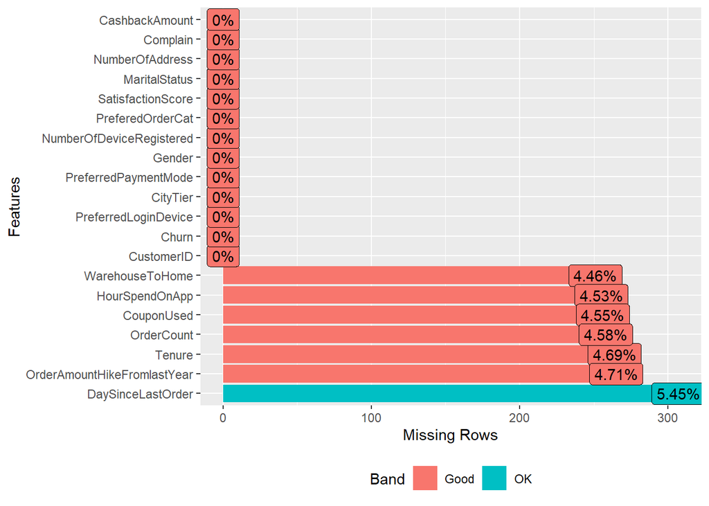

```r
plot_missing (dataset)
```

Checking for duplicates

```r
sum(duplicated(dataset))
```

```
## [1] 0
```

# PRE-PROCESSING

Converting categorical variables as factors

```r
dataset$Churn <- as.factor(dataset$Churn)
dataset$PreferredLoginDevice <- as.factor(dataset$PreferredLoginDevice)
dataset$CityTier <- as.factor(dataset$CityTier)
dataset$PreferredPaymentMode <- as.factor(dataset$PreferredPaymentMode)
dataset$Gender <- as.factor(dataset$Gender)
dataset$PreferedOrderCat <- as.factor(dataset$PreferedOrderCat)
dataset$SatisfactionScore <- as.factor(dataset$SatisfactionScore)
dataset$MaritalStatus <- as.factor(dataset$MaritalStatus)
dataset$Complain <- as.factor(dataset$Complain)

# Double checking the dataset structure again
str(dataset)
```

```
## tibble [5,630 x 20] (S3: tbl_df/tbl/data.frame)
##  $ CustomerID                 : num [1:5630] 50001 50002 50003 50004 50005 ...
##  $ Churn                      : Factor w/ 2 levels "0","1": 2 2 2 2 2 2 2 2 2 2 ...
##  $ Tenure                     : num [1:5630] 4 NA NA 0 0 0 NA NA 13 NA ...
##  $ PreferredLoginDevice       : Factor w/ 3 levels "Computer","Mobile Phone",..: 2 3 3 3 3 1 3 3 3 3 ...
##  $ CityTier                   : Factor w/ 3 levels "1","2","3": 3 1 1 3 1 1 3 1 3 1 ...
##  $ WarehouseToHome            : num [1:5630] 6 8 30 15 12 22 11 6 9 31 ...
##  $ PreferredPaymentMode       : Factor w/ 7 levels "Cash on Delivery",..: 5 7 5 5 2 5 1 2 6 5 ...
##  $ Gender                     : Factor w/ 2 levels "Female","Male": 1 2 2 2 2 1 2 2 2 2 ...
##  $ HourSpendOnApp             : num [1:5630] 3 3 2 2 NA 3 2 3 NA 2 ...
##  $ NumberOfDeviceRegistered   : num [1:5630] 3 4 4 4 3 5 3 3 4 5 ...
##  $ PreferedOrderCat           : Factor w/ 6 levels "Fashion","Grocery",..: 3 4 4 3 4 5 3 4 4 4 ...
##  $ SatisfactionScore          : Factor w/ 5 levels "1","2","3","4",..: 2 3 3 5 5 5 2 2 3 3 ...
##  $ MaritalStatus              : Factor w/ 3 levels "Divorced","Married",..: 3 3 3 3 3 3 1 1 1 3 ...
##  $ NumberOfAddress            : num [1:5630] 9 7 6 8 3 2 4 3 2 2 ...
##  $ Complain                   : Factor w/ 2 levels "0","1": 2 2 2 1 1 2 1 2 2 1 ...
##  $ OrderAmountHikeFromlastYear: num [1:5630] 11 15 14 23 11 22 14 16 14 12 ...
##  $ CouponUsed                 : num [1:5630] 1 0 0 0 0 4 0 2 0 1 ...
##  $ OrderCount                 : num [1:5630] 1 1 1 1 1 6 1 2 1 1 ...
##  $ DaySinceLastOrder          : num [1:5630] 5 0 3 3 3 7 0 0 2 1 ...
##  $ CashbackAmount             : num [1:5630] 160 121 120 134 130 ...
```

```r
summary(dataset)
```

```
##    CustomerID    Churn        Tenure        PreferredLoginDevice CityTier
##  Min.   :50001   0:4682   Min.   : 0.00   Computer    :1634      1:3666
##  1st Qu.:51408   1: 948   1st Qu.: 2.00   Mobile Phone:2765      2: 242
##  Median :52816            Median : 9.00   Phone       :1231      3:1722
##  Mean   :52816            Mean   :10.19
##  3rd Qu.:54223            3rd Qu.:16.00
##  Max.   :55630            Max.   :61.00
##                           NA's   :264
##  WarehouseToHome        PreferredPaymentMode    Gender     HourSpendOnApp
##  Min.   :  5.00   Cash on Delivery: 149      Female:2246   Min.   :0.000
##  1st Qu.:  9.00   CC              : 273      Male  :3384   1st Qu.:2.000
##  Median : 14.00   COD             : 365                    Median :3.000
##  Mean   : 15.64   Credit Card     :1501                    Mean   :2.932
##  3rd Qu.: 20.00   Debit Card      :2314                    3rd Qu.:3.000
##  Max.   :127.00   E wallet        : 614                    Max.   :5.000
##  NA's   :251      UPI             : 414                    NA's   :255
##  NumberOfDeviceRegistered           PreferedOrderCat SatisfactionScore
##  Min.   :1.000            Fashion           : 826    1:1164
##  1st Qu.:3.000            Grocery           : 410    2: 586
##  Median :4.000            Laptop & Accessory:2050    3:1698
##  Mean   :3.689            Mobile            : 809    4:1074
##  3rd Qu.:4.000            Mobile Phone      :1271    5:1108
##  Max.   :6.000            Others            : 264
##
##   MaritalStatus  NumberOfAddress  Complain OrderAmountHikeFromlastYear
##  Divorced: 848   Min.   : 1.000   0:4026   Min.   :11.00
##  Married :2986   1st Qu.: 2.000   1:1604   1st Qu.:13.00
##  Single  :1796   Median : 3.000            Median :15.00
##                  Mean   : 4.214            Mean   :15.71
##                  3rd Qu.: 6.000            3rd Qu.:18.00
##                  Max.   :22.000            Max.   :26.00
##                                            NA's   :265
##    CouponUsed       OrderCount     DaySinceLastOrder CashbackAmount
##  Min.   : 0.000   Min.   : 1.000   Min.   : 0.000    Min.   :  0.0
##  1st Qu.: 1.000   1st Qu.: 1.000   1st Qu.: 2.000    1st Qu.:145.8
##  Median : 1.000   Median : 2.000   Median : 3.000    Median :163.3
##  Mean   : 1.751   Mean   : 3.008   Mean   : 4.543    Mean   :177.2
##  3rd Qu.: 2.000   3rd Qu.: 3.000   3rd Qu.: 7.000    3rd Qu.:196.4
##  Max.   :16.000   Max.   :16.000   Max.   :46.000    Max.   :325.0
##  NA's   :256      NA's   :258      NA's   :307
```

Removal of CustomerID column, as not needed for the analysis

```r
dataset2 <- dataset
dataset2$CustomerID <- NULL
```

Imputing missing values

```r
imputed_df <- mice(dataset2, m=5)
dataset2 <- complete (imputed_df)

# Double check new imputed dataset
colSums(sapply(dataset2,is.na))
```

```
##                       Churn                      Tenure
##                           0                           0
##        PreferredLoginDevice                    CityTier
##                           0                           0
##             WarehouseToHome        PreferredPaymentMode
##                           0                           0
##                      Gender              HourSpendOnApp
##                           0                           0
##    NumberOfDeviceRegistered            PreferedOrderCat
##                           0                           0
##           SatisfactionScore               MaritalStatus
##                           0                           0
##             NumberOfAddress                    Complain
##                           0                           0
## OrderAmountHikeFromlastYear                  CouponUsed
##                           0                           0
##                  OrderCount           DaySinceLastOrder
##                           0                           0
##              CashbackAmount
##                           0
```

Dealing with Data Inconsistencies

```r
# Based on the summary statistics, there are data inconsistencies in the PreferredLoginDevice, PreferredPaymentMode and PreferedOrderCat variables. The category "Mobile Phone" & "Phone" and "Mobile" & "Mobile Phone" in the PreferredLoginDevice and PreferedOrderCat variables respectively are essentially the same thing. While the category "CC" & "Credit Card" as well as "COD" & "Cash on Delivery" in the PreferredPaymentMode variables are the same. These inconsistencies will be resolved by combining the similar categories together.

dataset2$PreferredLoginDevice <- factor(dataset2$PreferredLoginDevice,
                          levels = c('Computer', 'Mobile Phone', 'Phone'),
                          labels = c('Computer', 'Mobile Phone', 'Mobile Phone'))

dataset2$PreferredPaymentMode <- factor(dataset2$PreferredPaymentMode,
                          levels = c('Cash on Delivery', 'CC', 'COD', 'Credit Card', 'Debit Card', 'E wallet', 'UPI'),
                          labels = c('COD', 'Credit Card', 'COD', 'Credit Card', 'Debit Card', 'E wallet', 'UPI'))

dataset2$PreferedOrderCat <- factor(dataset2$PreferedOrderCat,
                          levels = c('Fashion', 'Grocery', 'Laptop & Accessory', 'Mobile', 'Mobile Phone', 'Others'),
                          labels = c('Fashion', 'Grocery', 'Laptop & Accessory', 'Mobile Phone', 'Mobile Phone', 'Others'))


# To double check data consistencies
summary(dataset2)
```

```
##  Churn        Tenure         PreferredLoginDevice CityTier WarehouseToHome
##  0:4682   Min.   : 0.000   Computer    :1634      1:3666   Min.   :  5.00
##  1: 948   1st Qu.: 2.000   Mobile Phone:3996      2: 242   1st Qu.:  9.00
##           Median : 8.000                          3:1722   Median : 14.00
##           Mean   : 9.962                                   Mean   : 15.62
##           3rd Qu.:15.000                                   3rd Qu.: 20.00
##           Max.   :61.000                                   Max.   :127.00
##   PreferredPaymentMode    Gender     HourSpendOnApp NumberOfDeviceRegistered
##  COD        : 514      Female:2246   Min.   :0.00   Min.   :1.000
##  Credit Card:1774      Male  :3384   1st Qu.:2.00   1st Qu.:3.000
##  Debit Card :2314                    Median :3.00   Median :4.000
##  E wallet   : 614                    Mean   :2.91   Mean   :3.689
##  UPI        : 414                    3rd Qu.:3.00   3rd Qu.:4.000
##                                      Max.   :5.00   Max.   :6.000
##            PreferedOrderCat SatisfactionScore  MaritalStatus  NumberOfAddress
##  Fashion           : 826    1:1164            Divorced: 848   Min.   : 1.000
##  Grocery           : 410    2: 586            Married :2986   1st Qu.: 2.000
##  Laptop & Accessory:2050    3:1698            Single  :1796   Median : 3.000
##  Mobile Phone      :2080    4:1074                            Mean   : 4.214
##  Others            : 264    5:1108                            3rd Qu.: 6.000
##                                                               Max.   :22.000
##  Complain OrderAmountHikeFromlastYear   CouponUsed       OrderCount
##  0:4026   Min.   :11.00               Min.   : 0.000   Min.   : 1.000
##  1:1604   1st Qu.:13.00               1st Qu.: 1.000   1st Qu.: 1.000
##           Median :15.00               Median : 1.000   Median : 2.000
##           Mean   :15.67               Mean   : 1.785   Mean   : 3.092
##           3rd Qu.:18.00               3rd Qu.: 2.000   3rd Qu.: 3.000
##           Max.   :26.00               Max.   :16.000   Max.   :16.000
##  DaySinceLastOrder CashbackAmount
##  Min.   : 0.000    Min.   :  0.0
##  1st Qu.: 2.000    1st Qu.:145.8
##  Median : 3.000    Median :163.3
##  Mean   : 4.653    Mean   :177.2
##  3rd Qu.: 8.000    3rd Qu.:196.4
##  Max.   :46.000    Max.   :325.0
```

# EDA

Histogram, Density, QQ-Plot, Frequency and Correlation Plots

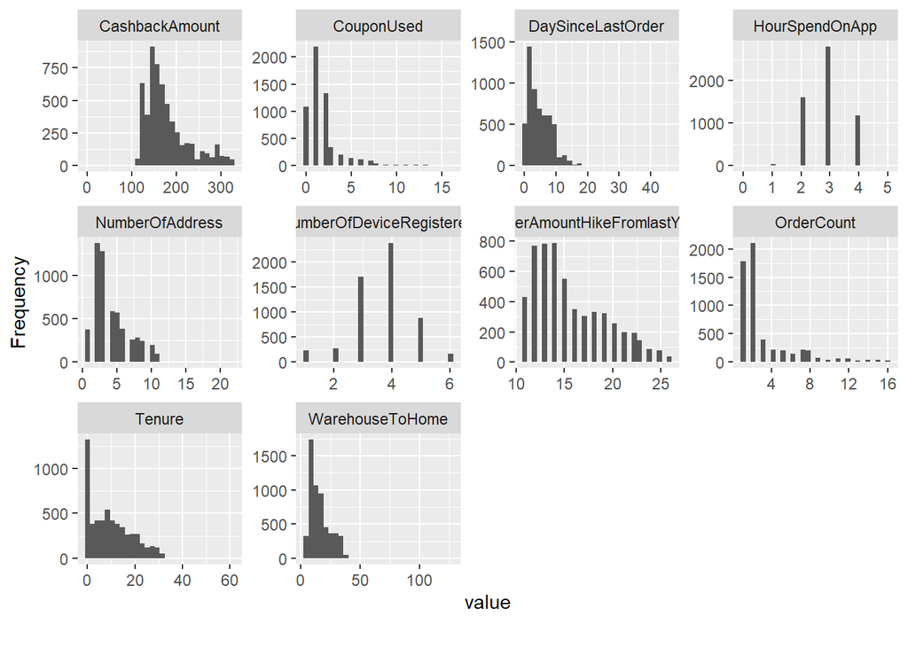

```r
plot_histogram(dataset2) # for numerical variables
```

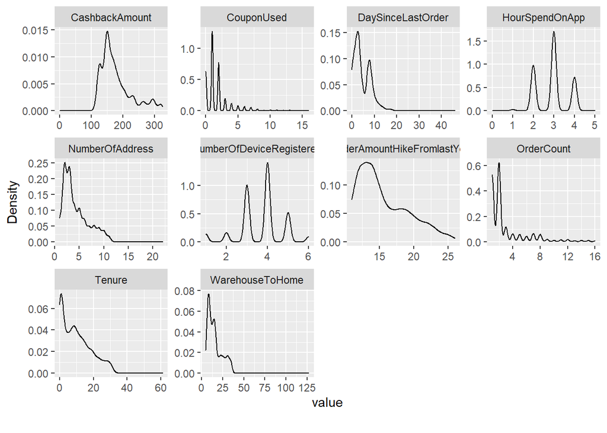

```r
plot_density(dataset2) # for numerical variables
```

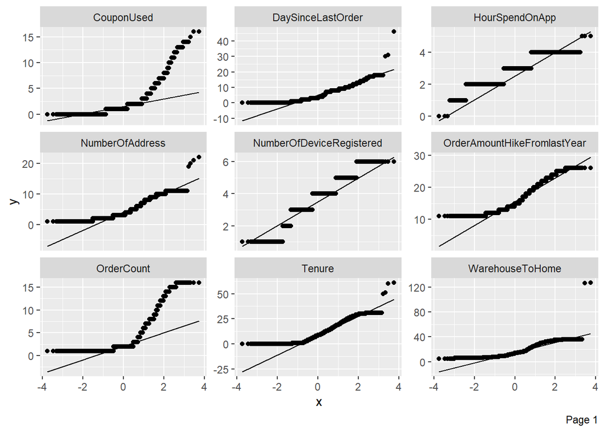

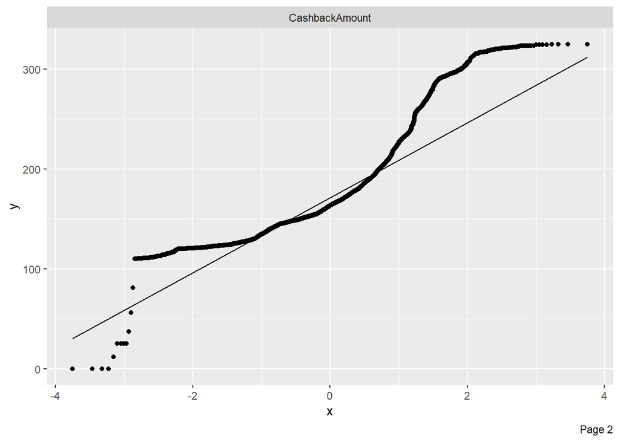

```r
plot_qq(dataset2) # for numerical variables
```

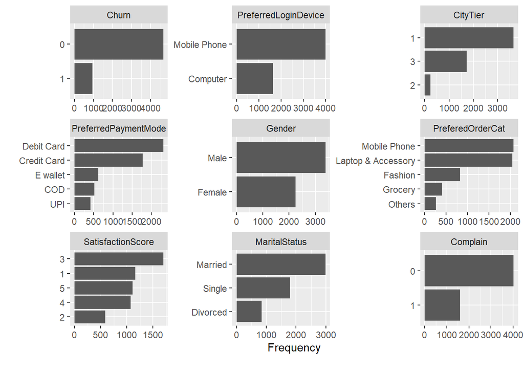

```r
plot_bar(dataset2) # for categorical variables
```

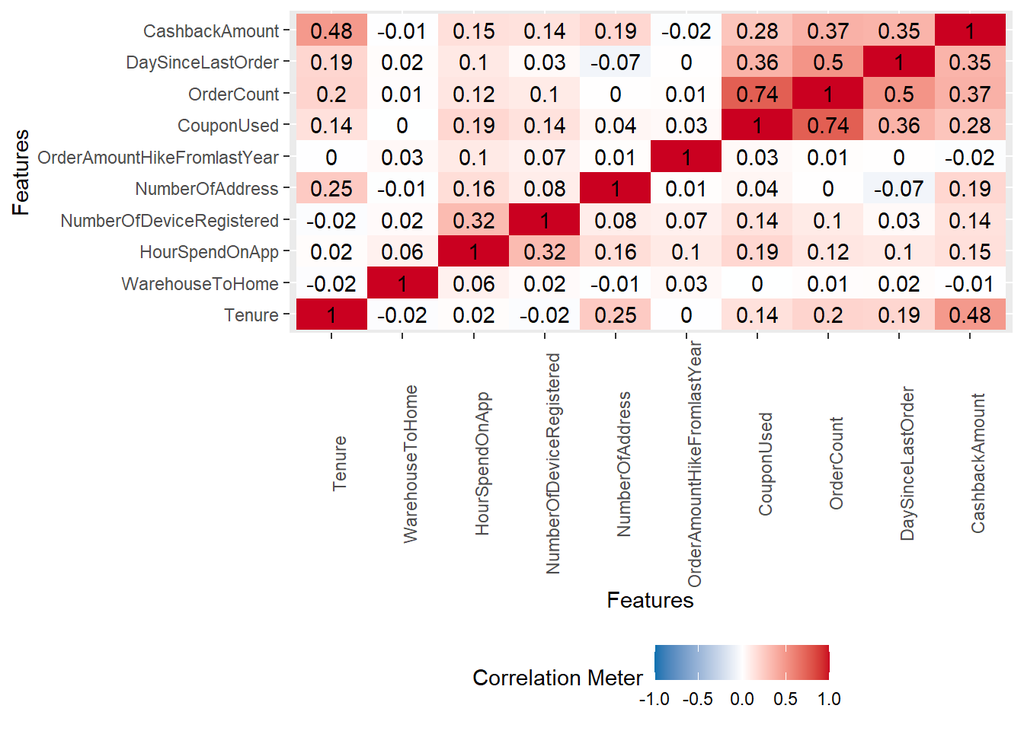

```r
plot_correlation(dataset2, type = 'continuous') # for numerical variables
```

Target variable observation per class

```r
freq = table(dataset2$Churn);freq
```

```
##
##    0    1
## 4682  948
```

```r
freq_per = prop.table(table(dataset2$Churn));freq_per
```

```
##
##         0         1
## 0.8316163 0.1683837
```

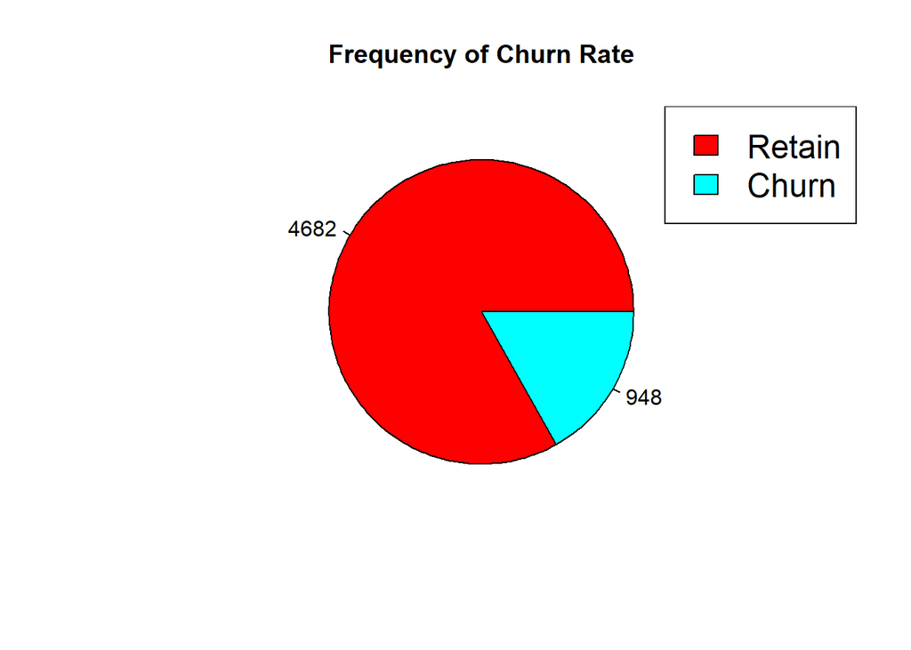

```r
pie(freq, main = 'Frequency of Churn Rate', label = freq, col = rainbow(2))
legend("topright", c("Retain","Churn"), cex = 1.5, fill = rainbow(2))
```

# FEATURE ENGINEERING & DATA PREPARATION

Label Encoding

```r
# Assign a new variable to dataset2 for easier coding process and reference
df <- dataset2

df$PreferredLoginDevice <- factor(df$PreferredLoginDevice,
                          levels = c('Computer', 'Mobile Phone'),
                          labels = c(0, 1))

df$PreferredPaymentMode <- factor(df$PreferredPaymentMode,
                          levels = c('COD', 'Credit Card', 'Debit Card', 'E wallet', 'UPI'),
                          labels = c(0, 1, 2, 3, 4))

df$PreferedOrderCat <- factor(df$PreferedOrderCat,
                          levels = c('Fashion', 'Grocery', 'Laptop & Accessory', 'Mobile Phone', 'Others'),
                          labels = c(0, 1, 2, 3, 4))

df$Gender <- factor(df$Gender,
                          levels = c('Female', 'Male'),
                          labels = c(0, 1))

df$MaritalStatus <- factor(df$MaritalStatus,
                          levels = c('Divorced', 'Married', 'Single'),
                          labels = c(0, 1, 2))
```

Log Transformation of positively skewed numeric variables

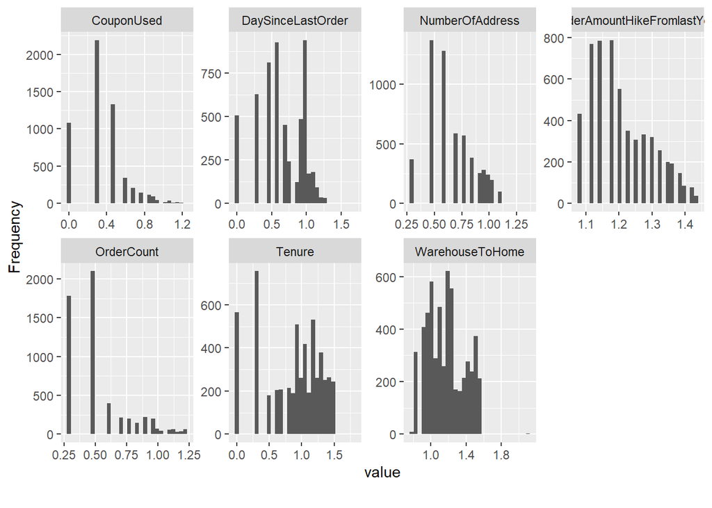

```r
log_trans <- log10(df[c(2,5,13,15,16,17,18)]+1)
plot_histogram(log_trans)
```

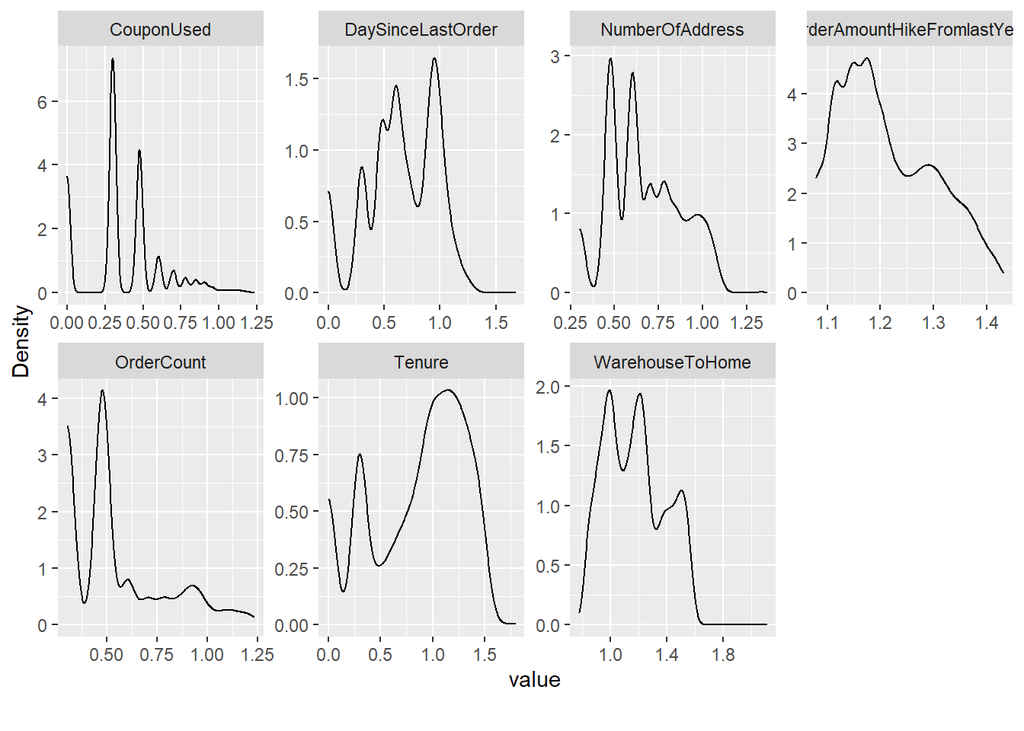

```r
plot_density(log_trans)
```

Log Transform original dataset

```r
df2 <- df
df2[, c(2,5,13,15,16,17,18)] <- log10(dataset2[, c(2,5,13,15,16,17,18)]+1)
```

Split data into training and testing sets - using Stratified Sampling

```r
# Initialize a pseudorandom number generator
set.seed(123)

# Initialize Stratified Sampling
split = sample.split(df2, SplitRatio = 0.7)
train = subset(df2, split == TRUE)
test = subset(df2, split == FALSE)

# View training & testing sets
summary(train)
```

```
##  Churn        Tenure       PreferredLoginDevice CityTier WarehouseToHome
##  0:3193   Min.   :0.0000   0:1098               1:2497   Min.   :0.7782
##  1: 658   1st Qu.:0.4771   1:2753               2: 167   1st Qu.:1.0000
##           Median :0.9542                        3:1187   Median :1.1761
##           Mean   :0.8552                                 Mean   :1.1731
##           3rd Qu.:1.2304                                 3rd Qu.:1.3424
##           Max.   :1.7924                                 Max.   :2.1038
##  PreferredPaymentMode Gender   HourSpendOnApp  NumberOfDeviceRegistered
##  0: 354               0:1557   Min.   :0.000   Min.   :1.00
##  1:1218               1:2294   1st Qu.:2.000   1st Qu.:3.00
##  2:1573                        Median :3.000   Median :4.00
##  3: 425                        Mean   :2.905   Mean   :3.68
##  4: 281                        3rd Qu.:3.000   3rd Qu.:4.00
##                                Max.   :5.000   Max.   :6.00
##  PreferedOrderCat SatisfactionScore MaritalStatus NumberOfAddress  Complain
##  0: 568           1: 793            0: 568        Min.   :0.3010   0:2756
##  1: 284           2: 431            1:2063        1st Qu.:0.4771   1:1095
##  2:1382           3:1151            2:1220        Median :0.6021
##  3:1427           4: 722                          Mean   :0.6690
##  4: 190           5: 754                          3rd Qu.:0.8451
##                                                   Max.   :1.3222
##  OrderAmountHikeFromlastYear   CouponUsed       OrderCount
##  Min.   :1.079               Min.   :0.0000   Min.   :0.3010
##  1st Qu.:1.146               1st Qu.:0.3010   1st Qu.:0.3010
##  Median :1.204               Median :0.3010   Median :0.4771
##  Mean   :1.211               Mean   :0.3660   Mean   :0.5335
##  3rd Qu.:1.279               3rd Qu.:0.4771   3rd Qu.:0.6021
##  Max.   :1.431               Max.   :1.2304   Max.   :1.2304
##  DaySinceLastOrder CashbackAmount
##  Min.   :0.0000    Min.   :  0.0
##  1st Qu.:0.4771    1st Qu.:145.7
##  Median :0.6021    Median :163.2
##  Mean   :0.6508    Mean   :177.7
##  3rd Qu.:0.9542    3rd Qu.:198.5
##  Max.   :1.5051    Max.   :325.0
```

```r
summary(test)
```

```
##  Churn        Tenure       PreferredLoginDevice CityTier WarehouseToHome
##  0:1489   Min.   :0.0000   0: 536               1:1169   Min.   :0.7782
##  1: 290   1st Qu.:0.4771   1:1243               2:  75   1st Qu.:1.0000
##           Median :0.9542                        3: 535   Median :1.1461
##           Mean   :0.8598                                 Mean   :1.1625
##           3rd Qu.:1.2041                                 3rd Qu.:1.3010
##           Max.   :1.5051                                 Max.   :2.1072
##  PreferredPaymentMode Gender   HourSpendOnApp  NumberOfDeviceRegistered
##  0:160                0: 689   Min.   :1.000   Min.   :1.000
##  1:556                1:1090   1st Qu.:2.000   1st Qu.:3.000
##  2:741                         Median :3.000   Median :4.000
##  3:189                         Mean   :2.918   Mean   :3.708
##  4:133                         3rd Qu.:3.000   3rd Qu.:4.000
##                                Max.   :4.000   Max.   :6.000
##  PreferedOrderCat SatisfactionScore MaritalStatus NumberOfAddress  Complain
##  0:258            1:371             0:280         Min.   :0.3010   0:1270
##  1:126            2:155             1:923         1st Qu.:0.4771   1: 509
##  2:668            3:547             2:576         Median :0.6021
##  3:653            4:352                           Mean   :0.6671
##  4: 74            5:354                           3rd Qu.:0.8451
##                                                   Max.   :1.3617
##  OrderAmountHikeFromlastYear   CouponUsed       OrderCount
##  Min.   :1.079               Min.   :0.0000   Min.   :0.3010
##  1st Qu.:1.146               1st Qu.:0.3010   1st Qu.:0.3010
##  Median :1.204               Median :0.3010   Median :0.4771
##  Mean   :1.213               Mean   :0.3707   Mean   :0.5327
##  3rd Qu.:1.279               3rd Qu.:0.4771   3rd Qu.:0.6021
##  Max.   :1.431               Max.   :1.2304   Max.   :1.2304
##  DaySinceLastOrder CashbackAmount
##  Min.   :0.0000    Min.   :  0.0
##  1st Qu.:0.4771    1st Qu.:145.8
##  Median :0.6021    Median :163.8
##  Mean   :0.6484    Mean   :176.2
##  3rd Qu.:0.9542    3rd Qu.:193.6
##  Max.   :1.6721    Max.   :324.7
```

```r
head(train)
```

```
##    Churn   Tenure PreferredLoginDevice CityTier WarehouseToHome
## 1      1 0.698970                    1        3        0.845098
## 3      1 0.000000                    1        1        1.491362
## 6      1 0.000000                    0        1        1.361728
## 7      1 0.000000                    1        3        1.079181
## 9      1 1.146128                    1        3        1.000000
## 10     1 0.000000                    1        1        1.505150
##    PreferredPaymentMode Gender HourSpendOnApp NumberOfDeviceRegistered
## 1                     2      0              3                        3
## 3                     2      1              2                        4
## 6                     2      0              3                        5
## 7                     0      1              2                        3
## 9                     3      1              2                        4
## 10                    2      1              2                        5
##    PreferedOrderCat SatisfactionScore MaritalStatus NumberOfAddress Complain
```

[output cut: 20 more lines]

```r
head(test)
```

```
##    Churn  Tenure PreferredLoginDevice CityTier WarehouseToHome
## 2      1 0.30103                    1        1       0.9542425
## 4      1 0.00000                    1        3       1.2041200
## 5      1 0.00000                    1        1       1.1139434
## 8      1 0.30103                    1        1       0.8450980
## 11     1 0.69897                    1        1       1.2787536
## 16     1 0.30103                    1        2       1.1139434
##    PreferredPaymentMode Gender HourSpendOnApp NumberOfDeviceRegistered
## 2                     4      1              3                        4
## 4                     2      1              2                        4
## 5                     1      1              1                        3
## 8                     1      1              3                        3
## 11                    0      0              2                        3
## 16                    4      1              3                        3
##    PreferedOrderCat SatisfactionScore MaritalStatus NumberOfAddress Complain
```

[output cut: 20 more lines]

```r
dim(train)
```

```
## [1] 3851   19
```

```r
dim(test)
```

```
## [1] 1779   19
```

Normalization of training set

```r
train2 <- train%>%
  mutate_at(c(2,5,8,9,13,15,16,17,18,19), funs((.-min(.))/max(.-min(.))))%>%
  mutate_if(is.numeric, round, digits = 3)
# To view summary statistic after normalization
summary(train2)
```

```
##  Churn        Tenure       PreferredLoginDevice CityTier WarehouseToHome
##  0:3193   Min.   :0.0000   0:1098               1:2497   Min.   :0.0000
##  1: 658   1st Qu.:0.2660   1:2753               2: 167   1st Qu.:0.1670
##           Median :0.5320                        3:1187   Median :0.3000
##           Mean   :0.4771                                 Mean   :0.2979
##           3rd Qu.:0.6860                                 3rd Qu.:0.4260
##           Max.   :1.0000                                 Max.   :1.0000
##  PreferredPaymentMode Gender   HourSpendOnApp   NumberOfDeviceRegistered
##  0: 354               0:1557   Min.   :0.0000   Min.   :0.0000
##  1:1218               1:2294   1st Qu.:0.4000   1st Qu.:0.4000
##  2:1573                        Median :0.6000   Median :0.6000
##  3: 425                        Mean   :0.5811   Mean   :0.5361
##  4: 281                        3rd Qu.:0.6000   3rd Qu.:0.6000
##                                Max.   :1.0000   Max.   :1.0000
##  PreferedOrderCat SatisfactionScore MaritalStatus NumberOfAddress  Complain
##  0: 568           1: 793            0: 568        Min.   :0.0000   0:2756
##  1: 284           2: 431            1:2063        1st Qu.:0.1720   1:1095
##  2:1382           3:1151            2:1220        Median :0.2950
##  3:1427           4: 722                          Mean   :0.3603
##  4: 190           5: 754                          3rd Qu.:0.5330
##                                                   Max.   :1.0000
##  OrderAmountHikeFromlastYear   CouponUsed       OrderCount
##  Min.   :0.0000              Min.   :0.0000   Min.   :0.0000
##  1st Qu.:0.1900              1st Qu.:0.2450   1st Qu.:0.0000
##  Median :0.3550              Median :0.2450   Median :0.1890
##  Mean   :0.3752              Mean   :0.2976   Mean   :0.2499
##  3rd Qu.:0.5670              3rd Qu.:0.3880   3rd Qu.:0.3240
##  Max.   :1.0000              Max.   :1.0000   Max.   :1.0000
##  DaySinceLastOrder CashbackAmount
##  Min.   :0.0000    Min.   :0.0000
##  1st Qu.:0.3170    1st Qu.:0.4480
##  Median :0.4000    Median :0.5020
##  Mean   :0.4323    Mean   :0.5468
##  3rd Qu.:0.6340    3rd Qu.:0.6110
##  Max.   :1.0000    Max.   :1.0000
```

Normalization of testing set

```r
test2 <- test%>%
  mutate_at(c(2,5,8,9,13,15,16,17,18,19), funs((.-min(.))/max(.-min(.))))%>%
  mutate_if(is.numeric, round, digits = 3)

# To view summary statistic after normalization
summary(test2)
```

```
##  Churn        Tenure       PreferredLoginDevice CityTier WarehouseToHome
##  0:1489   Min.   :0.0000   0: 536               1:1169   Min.   :0.0000
##  1: 290   1st Qu.:0.3170   1:1243               2:  75   1st Qu.:0.1670
##           Median :0.6340                        3: 535   Median :0.2770
##           Mean   :0.5711                                 Mean   :0.2891
##           3rd Qu.:0.8000                                 3rd Qu.:0.3930
##           Max.   :1.0000                                 Max.   :1.0000
##  PreferredPaymentMode Gender   HourSpendOnApp   NumberOfDeviceRegistered
##  0:160                0: 689   Min.   :0.0000   Min.   :0.0000
##  1:556                1:1090   1st Qu.:0.3330   1st Qu.:0.4000
##  2:741                         Median :0.6670   Median :0.6000
##  3:189                         Mean   :0.6396   Mean   :0.5415
##  4:133                         3rd Qu.:0.6670   3rd Qu.:0.6000
##                                Max.   :1.0000   Max.   :1.0000
##  PreferedOrderCat SatisfactionScore MaritalStatus NumberOfAddress  Complain
##  0:258            1:371             0:280         Min.   :0.0000   0:1270
##  1:126            2:155             1:923         1st Qu.:0.1660   1: 509
##  2:668            3:547             2:576         Median :0.2840
##  3:653            4:352                           Mean   :0.3452
##  4: 74            5:354                           3rd Qu.:0.5130
##                                                   Max.   :1.0000
##  OrderAmountHikeFromlastYear   CouponUsed       OrderCount
##  Min.   :0.0000              Min.   :0.0000   Min.   :0.0000
##  1st Qu.:0.1900              1st Qu.:0.2450   1st Qu.:0.0000
##  Median :0.3550              Median :0.2450   Median :0.1890
##  Mean   :0.3813              Mean   :0.3014   Mean   :0.2491
##  3rd Qu.:0.5670              3rd Qu.:0.3880   3rd Qu.:0.3240
##  Max.   :1.0000              Max.   :1.0000   Max.   :1.0000
##  DaySinceLastOrder CashbackAmount
##  Min.   :0.0000    Min.   :0.0000
##  1st Qu.:0.2850    1st Qu.:0.4490
##  Median :0.3600    Median :0.5040
##  Mean   :0.3877    Mean   :0.5426
##  3rd Qu.:0.5710    3rd Qu.:0.5960
##  Max.   :1.0000    Max.   :1.0000
```

Data Balancing training set using ROSE

```r
#ROSE helps us to generate data synthetically (without duplicates) to provide better estimate of original data.
data_balanced <- ROSE(Churn ~ ., data = train, p=0.5, N=3851, seed = 1)$data

# To view output result after data balancing
table(data_balanced$Churn)
```

```
##
##    0    1
## 1981 1870
```

```r
prop.table(table(data_balanced$Churn))
```

```
##
##         0         1
## 0.5144118 0.4855882
```

```r
sum(duplicated(data_balanced))
```

```
## [1] 0
```

Data Balancing normalized training set using ROSE

```r
#ROSE helps us to generate data synthetically (without duplicates) to provide better estimate of original data.
data_balanced2 <- ROSE(Churn ~ ., data = train2, p=0.5, N=3851, seed = 1)$data

# To view output result after data balancing (normalized)
table(data_balanced2$Churn)
```

```
##
##    0    1
## 1981 1870
```

```r
prop.table(table(data_balanced2$Churn))
```

```
##
##         0         1
## 0.5144118 0.4855882
```

```r
sum(duplicated(data_balanced2))
```

```
## [1] 0
```

# MODELLING

Logistic Regression

```r
# Building LoR classifier
LoR_classifier = glm(data_balanced2$Churn ~.,
                 data_balanced2,
                 family = binomial) # use data_balanced2 (normalized) dataset as LoR is highly influence by scales

# To view output of model
summary(LoR_classifier)
```

```
##
## Call:
## glm(formula = data_balanced2$Churn ~ ., family = binomial, data = data_balanced2)
##
## Deviance Residuals:
##     Min       1Q   Median       3Q      Max
## -2.9043  -0.6378  -0.1297   0.5918   3.2420
##
## Coefficients:
##                             Estimate Std. Error z value Pr(>|z|)
## (Intercept)                  0.85467    0.44059   1.940 0.052400 .
## Tenure                      -4.46702    0.19679 -22.699  < 2e-16 ***
## PreferredLoginDevice1       -0.33664    0.09874  -3.409 0.000651 ***
## CityTier2                    0.43692    0.24082   1.814 0.069630 .
## CityTier3                    0.37806    0.12098   3.125 0.001779 **
## WarehouseToHome              1.92440    0.26616   7.230 4.82e-13 ***
## PreferredPaymentMode1       -0.95636    0.16901  -5.659 1.53e-08 ***
## PreferredPaymentMode2       -0.98561    0.16412  -6.006 1.91e-09 ***
## PreferredPaymentMode3       -0.17522    0.20758  -0.844 0.398603
## PreferredPaymentMode4       -0.89778    0.22311  -4.024 5.73e-05 ***
## Gender1                      0.47149    0.09422   5.004 5.61e-07 ***
## HourSpendOnApp              -0.43612    0.30062  -1.451 0.146849
## NumberOfDeviceRegistered     1.52443    0.21108   7.222 5.11e-13 ***
## PreferedOrderCat1           -0.94667    0.25758  -3.675 0.000238 ***
## PreferedOrderCat2           -1.43402    0.15882  -9.029  < 2e-16 ***
## PreferedOrderCat3           -0.39657    0.17783  -2.230 0.025739 *
## PreferedOrderCat4            0.36259    0.30023   1.208 0.227162
## SatisfactionScore2          -0.51442    0.18917  -2.719 0.006542 **
## SatisfactionScore3           0.44504    0.13474   3.303 0.000957 ***
## SatisfactionScore4           0.87526    0.15356   5.700 1.20e-08 ***
## SatisfactionScore5           1.04042    0.14564   7.144 9.07e-13 ***
## MaritalStatus1              -0.43111    0.13832  -3.117 0.001829 **
## MaritalStatus2               0.54252    0.13932   3.894 9.86e-05 ***
## NumberOfAddress              2.18329    0.20987  10.403  < 2e-16 ***
## Complain1                    1.55871    0.09500  16.407  < 2e-16 ***
## OrderAmountHikeFromlastYear -0.09834    0.15028  -0.654 0.512886
## CouponUsed                  -0.01015    0.24019  -0.042 0.966291
## OrderCount                   0.67305    0.20383   3.302 0.000960 ***
## DaySinceLastOrder           -1.41513    0.21511  -6.579 4.75e-11 ***
## CashbackAmount              -1.28398    0.49636  -2.587 0.009687 **
## ---
## Signif. codes:  0 '***' 0.001 '**' 0.01 '*' 0.05 '.' 0.1 ' ' 1
##
## (Dispersion parameter for binomial family taken to be 1)
##
##     Null deviance: 5335.4  on 3850  degrees of freedom
## Residual deviance: 3172.4  on 3821  degrees of freedom
## AIC: 3232.4
##
## Number of Fisher Scoring iterations: 5
```

LoR Train & Test Validation

```r
# Predicting for train set results
pred_prob_LoR_training <- predict(LoR_classifier, type = 'response', data_balanced2[ ,-1])
pred_class_LoR_training = ifelse(pred_prob_LoR_training > 0.5, 1, 0)
cbind(pred_prob_LoR_training, pred_class_LoR_training)
```

```
##      pred_prob_LoR_training pred_class_LoR_training
## 1              0.0189903329                       0
## 2              0.1969873672                       0
## 3              0.0717395880                       0
## 4              0.4586382405                       0
## 5              0.0848690179                       0
## 6              0.0160117515                       0
## 7              0.0160950068                       0
## 8              0.0580609189                       0
## 9              0.2274244067                       0
## 10             0.2228261442                       0
## 11             0.0345186132                       0
## 12             0.1033105321                       0
## 13             0.0864181075                       0
## 14             0.2729440661                       0
```

[output cut: 3837 more lines]

```r
cm_LoR_training = table(pred_class_LoR_training, data_balanced2$Churn)
# Confusion matrix for train set
confusionMatrix(cm_LoR_training, mode = "everything")
```

```
## Confusion Matrix and Statistics
##
##
## pred_class_LoR_training    0    1
##                       0 1644  360
##                       1  337 1510
##
##                Accuracy : 0.819
##                  95% CI : (0.8065, 0.8311)
##     No Information Rate : 0.5144
##     P-Value [Acc > NIR] : <2e-16
##
##                   Kappa : 0.6376
##
##  Mcnemar's Test P-Value : 0.4047
##
##             Sensitivity : 0.8299
##             Specificity : 0.8075
##          Pos Pred Value : 0.8204
##          Neg Pred Value : 0.8175
##               Precision : 0.8204
##                  Recall : 0.8299
##                      F1 : 0.8251
##              Prevalence : 0.5144
##          Detection Rate : 0.4269
##    Detection Prevalence : 0.5204
##       Balanced Accuracy : 0.8187
##
##        'Positive' Class : 0
##
```

```r
# Predicting for test set results
pred_prob_LoR_testing <- predict(LoR_classifier, type = 'response', test2[ ,-1])
pred_class_LoR_testing = ifelse(pred_prob_LoR_testing > 0.5, 1, 0)
cbind(pred_prob_LoR_testing, pred_class_LoR_testing)
```

```
##      pred_prob_LoR_testing pred_class_LoR_testing
## 2              0.950422880                      1
## 4              0.894649980                      1
## 5              0.871520184                      1
## 8              0.602761599                      1
## 11             0.360255515                      0
## 16             0.903141642                      1
## 21             0.910480750                      1
## 23             0.990395724                      1
## 24             0.910410443                      1
## 27             0.196686865                      0
## 30             0.240544746                      0
## 35             0.246416873                      0
## 40             0.903121957                      1
## 42             0.035654836                      0
```

[output cut: 1765 more lines]

```r
cm_LoR_testing = table(pred_class_LoR_testing, test2$Churn)
# Confusion matrix for test set
confusionMatrix(cm_LoR_testing, mode = "everything")
```

```
## Confusion Matrix and Statistics
##
##
## pred_class_LoR_testing    0    1
##                      0 1307   52
##                      1  182  238
##
##                Accuracy : 0.8685
##                  95% CI : (0.8519, 0.8838)
##     No Information Rate : 0.837
##     P-Value [Acc > NIR] : 0.0001285
##
##                   Kappa : 0.5917
##
##  Mcnemar's Test P-Value : < 2.2e-16
##
##             Sensitivity : 0.8778
##             Specificity : 0.8207
##          Pos Pred Value : 0.9617
##          Neg Pred Value : 0.5667
##               Precision : 0.9617
##                  Recall : 0.8778
##                      F1 : 0.9178
##              Prevalence : 0.8370
##          Detection Rate : 0.7347
##    Detection Prevalence : 0.7639
##       Balanced Accuracy : 0.8492
##
##        'Positive' Class : 0
##
```

LoR ROC Curve & AUC

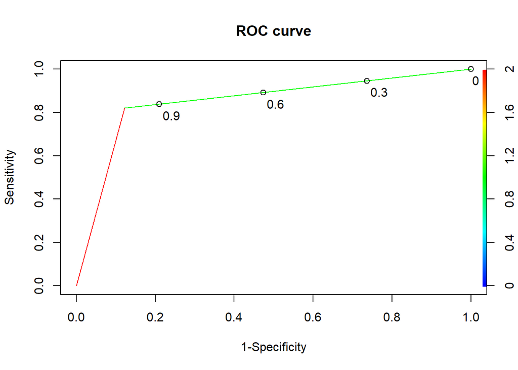

```r
# LoR ROC Curve
pred_LoR = prediction(pred_class_LoR_testing, test2$Churn)
perf_LoR = performance(pred_LoR, "tpr", "fpr")

plot(perf_LoR, colorize=T,
     main = "ROC curve",
     ylab = "Sensitivity",
     xlab = "1-Specificity",
     print.cutoffs.at=seq(0,1,0.3),
     text.adj= c(-0.2,1.7))
```

```r
# LoR AUC
auc_LoR <- as.numeric(performance(pred_LoR, "auc")@y.values)
auc_LoR <- round(auc_LoR, 3)
auc_LoR
```

```
## [1] 0.849
```

SVM - RBF

```r
# Building Default SVM RBF Kernal
svm_rbf <- svm(data_balanced2$Churn ~., data = data_balanced2) # use data_balanced2 (normalized) dataset as SVM is highly influence by scales

# To view output of model
summary(svm_rbf)
```

```
##
## Call:
## svm(formula = data_balanced2$Churn ~ ., data = data_balanced2)
##
##
## Parameters:
##    SVM-Type:  C-classification
##  SVM-Kernel:  radial
##        cost:  1
##
## Number of Support Vectors:  1804
##
##  ( 910 894 )
##
##
## Number of Classes:  2
##
## Levels:
##  0 1
```

```r
svm_rbf$gamma
```

```
## [1] 0.03333333
```

```r
# Train prediction & confusion matrix
pred_svm_rbf_train = predict (svm_rbf, data_balanced2)

confusionMatrix(table(pred_svm_rbf_train, data_balanced2$Churn), mode = "everything")
```

```
## Confusion Matrix and Statistics
##
##
## pred_svm_rbf_train    0    1
##                  0 1789  290
##                  1  192 1580
##
##                Accuracy : 0.8748
##                  95% CI : (0.864, 0.8851)
##     No Information Rate : 0.5144
##     P-Value [Acc > NIR] : < 2.2e-16
##
##                   Kappa : 0.7491
##
##  Mcnemar's Test P-Value : 9.951e-06
##
##             Sensitivity : 0.9031
##             Specificity : 0.8449
##          Pos Pred Value : 0.8605
##          Neg Pred Value : 0.8916
##               Precision : 0.8605
##                  Recall : 0.9031
##                      F1 : 0.8813
##              Prevalence : 0.5144
##          Detection Rate : 0.4646
##    Detection Prevalence : 0.5399
##       Balanced Accuracy : 0.8740
##
##        'Positive' Class : 0
##
```

```r
# Test prediction & confusion matrix
pred_svm_rbf_test = predict (svm_rbf, test2)

confusionMatrix(table(pred_svm_rbf_test, test2$Churn), mode = "everything")
```

```
## Confusion Matrix and Statistics
##
##
## pred_svm_rbf_test    0    1
##                 0 1368   64
##                 1  121  226
##
##                Accuracy : 0.896
##                  95% CI : (0.8809, 0.9098)
##     No Information Rate : 0.837
##     P-Value [Acc > NIR] : 6.658e-13
##
##                   Kappa : 0.6469
##
##  Mcnemar's Test P-Value : 3.835e-05
##
##             Sensitivity : 0.9187
##             Specificity : 0.7793
##          Pos Pred Value : 0.9553
##          Neg Pred Value : 0.6513
##               Precision : 0.9553
##                  Recall : 0.9187
##                      F1 : 0.9367
##              Prevalence : 0.8370
##          Detection Rate : 0.7690
##    Detection Prevalence : 0.8049
##       Balanced Accuracy : 0.8490
##
##        'Positive' Class : 0
##
```

SVM - Linear

```r
# Linear Kernal
svm_linear <- svm(data_balanced2$Churn ~., data = data_balanced2, kernel = "linear") # use data_balanced2 (normalized) dataset as SVM is highly influence by scaling
summary(svm_linear)
```

```
##
## Call:
## svm(formula = data_balanced2$Churn ~ ., data = data_balanced2, kernel = "linear")
##
##
## Parameters:
##    SVM-Type:  C-classification
##  SVM-Kernel:  linear
##        cost:  1
##
## Number of Support Vectors:  1694
##
##  ( 848 846 )
##
##
## Number of Classes:  2
##
## Levels:
##  0 1
```

```r
svm_linear$gamma
```

```
## [1] 0.03333333
```

```r
# Train prediction & confusion matrix
pred_svm_linear_train = predict (svm_linear, data_balanced2)

confusionMatrix(table(pred_svm_linear_train, data_balanced2$Churn))
```

```
## Confusion Matrix and Statistics
##
##
## pred_svm_linear_train    0    1
##                     0 1680  371
##                     1  301 1499
##
##                Accuracy : 0.8255
##                  95% CI : (0.8131, 0.8374)
##     No Information Rate : 0.5144
##     P-Value [Acc > NIR] : < 2.2e-16
##
##                   Kappa : 0.6503
##
##  Mcnemar's Test P-Value : 0.007774
##
##             Sensitivity : 0.8481
##             Specificity : 0.8016
##          Pos Pred Value : 0.8191
##          Neg Pred Value : 0.8328
##              Prevalence : 0.5144
##          Detection Rate : 0.4363
##    Detection Prevalence : 0.5326
##       Balanced Accuracy : 0.8248
##
##        'Positive' Class : 0
##
```

```r
# Test prediction & confusion matrix
pred_svm_linear_test = predict (svm_linear, test2)

confusionMatrix(table(pred_svm_linear_test, test2$Churn))
```

```
## Confusion Matrix and Statistics
##
##
## pred_svm_linear_test    0    1
##                    0 1321   56
##                    1  168  234
##
##                Accuracy : 0.8741
##                  95% CI : (0.8578, 0.8892)
##     No Information Rate : 0.837
##     P-Value [Acc > NIR] : 7.156e-06
##
##                   Kappa : 0.6007
##
##  Mcnemar's Test P-Value : 1.203e-13
##
##             Sensitivity : 0.8872
##             Specificity : 0.8069
##          Pos Pred Value : 0.9593
##          Neg Pred Value : 0.5821
##              Prevalence : 0.8370
##          Detection Rate : 0.7426
##    Detection Prevalence : 0.7740
##       Balanced Accuracy : 0.8470
##
##        'Positive' Class : 0
##
```

SVM - Sigmoid

```r
# Sigmoid Kernal
svm_sigmoid <- svm(data_balanced2$Churn ~., data = data_balanced2, kernel = "sigmoid") # use data_balanced2 (normalized) dataset as SVM is highly influence by scaling
summary(svm_sigmoid)
```

```
##
## Call:
## svm(formula = data_balanced2$Churn ~ ., data = data_balanced2, kernel = "sigmoid")
##
##
## Parameters:
##    SVM-Type:  C-classification
##  SVM-Kernel:  sigmoid
##        cost:  1
##      coef.0:  0
##
## Number of Support Vectors:  1745
##
##  ( 871 874 )
##
##
## Number of Classes:  2
##
## Levels:
##  0 1
```

```r
svm_sigmoid$gamma
```

```
## [1] 0.03333333
```

```r
# Train prediction & confusion matrix
pred_svm_sigmoid_train = predict (svm_sigmoid, data_balanced2)

confusionMatrix(table(pred_svm_sigmoid_train, data_balanced2$Churn))
```

```
## Confusion Matrix and Statistics
##
##
## pred_svm_sigmoid_train    0    1
##                      0 1588  447
##                      1  393 1423
##
##                Accuracy : 0.7819
##                  95% CI : (0.7685, 0.7948)
##     No Information Rate : 0.5144
##     P-Value [Acc > NIR] : < 2e-16
##
##                   Kappa : 0.563
##
##  Mcnemar's Test P-Value : 0.06745
##
##             Sensitivity : 0.8016
##             Specificity : 0.7610
##          Pos Pred Value : 0.7803
##          Neg Pred Value : 0.7836
##              Prevalence : 0.5144
##          Detection Rate : 0.4124
##    Detection Prevalence : 0.5284
##       Balanced Accuracy : 0.7813
##
##        'Positive' Class : 0
##
```

```r
# Test prediction & confusion matrix
pred_svm_sigmoid_test = predict (svm_sigmoid, test2)

confusionMatrix(table(pred_svm_sigmoid_test, test2$Churn))
```

```
## Confusion Matrix and Statistics
##
##
## pred_svm_sigmoid_test    0    1
##                     0 1295   61
##                     1  194  229
##
##                Accuracy : 0.8567
##                  95% CI : (0.8395, 0.8726)
##     No Information Rate : 0.837
##     P-Value [Acc > NIR] : 0.0124
##
##                   Kappa : 0.5566
##
##  Mcnemar's Test P-Value : <2e-16
##
##             Sensitivity : 0.8697
##             Specificity : 0.7897
##          Pos Pred Value : 0.9550
##          Neg Pred Value : 0.5414
##              Prevalence : 0.8370
##          Detection Rate : 0.7279
##    Detection Prevalence : 0.7622
##       Balanced Accuracy : 0.8297
##
##        'Positive' Class : 0
##
```

SVM - Polynomial

```r
# Polynomial Kernal
svm_poly <- svm(data_balanced2$Churn ~., data = data_balanced2, kernel = "poly") # use data_balanced2 (normalized) dataset as SVM is highly influence by scaling
summary(svm_poly)
```

```
##
## Call:
## svm(formula = data_balanced2$Churn ~ ., data = data_balanced2, kernel = "poly")
##
##
## Parameters:
##    SVM-Type:  C-classification
##  SVM-Kernel:  polynomial
##        cost:  1
##      degree:  3
##      coef.0:  0
##
## Number of Support Vectors:  2501
##
##  ( 1260 1241 )
##
##
## Number of Classes:  2
##
## Levels:
##  0 1
```

```r
svm_poly$gamma
```

```
## [1] 0.03333333
```

```r
# Train prediction & confusion matrix
pred_svm_poly_train = predict (svm_poly, data_balanced2)

confusionMatrix(table(pred_svm_poly_train, data_balanced2$Churn))
```

```
## Confusion Matrix and Statistics
##
##
## pred_svm_poly_train    0    1
##                   0 1846  354
##                   1  135 1516
##
##                Accuracy : 0.873
##                  95% CI : (0.8621, 0.8834)
##     No Information Rate : 0.5144
##     P-Value [Acc > NIR] : < 2.2e-16
##
##                   Kappa : 0.745
##
##  Mcnemar's Test P-Value : < 2.2e-16
##
##             Sensitivity : 0.9319
##             Specificity : 0.8107
##          Pos Pred Value : 0.8391
##          Neg Pred Value : 0.9182
##              Prevalence : 0.5144
##          Detection Rate : 0.4794
##    Detection Prevalence : 0.5713
##       Balanced Accuracy : 0.8713
##
##        'Positive' Class : 0
##
```

```r
# Test prediction & confusion matrix
pred_svm_poly_test = predict (svm_poly, test2)

confusionMatrix(table(pred_svm_poly_test, test2$Churn))
```

```
## Confusion Matrix and Statistics
##
##
## pred_svm_poly_test    0    1
##                  0 1389   69
##                  1  100  221
##
##                Accuracy : 0.905
##                  95% CI : (0.8904, 0.9182)
##     No Information Rate : 0.837
##     P-Value [Acc > NIR] : < 2e-16
##
##                   Kappa : 0.6662
##
##  Mcnemar's Test P-Value : 0.02102
##
##             Sensitivity : 0.9328
##             Specificity : 0.7621
##          Pos Pred Value : 0.9527
##          Neg Pred Value : 0.6885
##              Prevalence : 0.8370
##          Detection Rate : 0.7808
##    Detection Prevalence : 0.8196
##       Balanced Accuracy : 0.8475
##
##        'Positive' Class : 0
##
```

Hyperparameter tuning (grid search)

```r
# Grid Search
set.seed(123)
svm_tuned_model = tune(svm, Churn ~., data = data_balanced2,
                   ranges = list(gamma = 2^(-1:1),
                                 cost = 2^(-1:1),
                                 kernel = c("radial", "linear", "sigmoid", "poly"))) # grid = 3 by 3 by 4 = 36 combinations (running 36 different SVMs)

# To view output of grid search
summary(svm_tuned_model)
```

```
##
## Parameter tuning of 'svm':
##
## - sampling method: 10-fold cross validation
##
## - best parameters:
##  gamma cost kernel
##    0.5    2 radial
##
## - best performance: 0.0766005
##
## - Detailed performance results:
##    gamma cost  kernel      error dispersion
## 1    0.5  0.5  radial 0.19631586 0.02751725
## 2    1.0  0.5  radial 0.48506426 0.01460588
```

[output cut: 34 more lines]

Building the best SVM model based on the best Kernal function and hyperparameter

```r
# Building Best SVM Model RBF Kernal
svm_best <- svm(data_balanced2$Churn~., data = data_balanced2, kernel = "radial", gamma = 0.5, cost = 2)

# To view output of model
summary(svm_best)
```

```
##
## Call:
## svm(formula = data_balanced2$Churn ~ ., data = data_balanced2, kernel = "radial",
##     gamma = 0.5, cost = 2)
##
##
## Parameters:
##    SVM-Type:  C-classification
##  SVM-Kernel:  radial
##        cost:  2
##
## Number of Support Vectors:  3783
##
##  ( 1958 1825 )
##
##
## Number of Classes:  2
##
## Levels:
##  0 1
```

Best SVM Train & Test Validation

```r
# Train prediction & confusion matrix
pred_svm_best_train = predict (svm_best, data_balanced2)

confusionMatrix(table(pred_svm_best_train, data_balanced2$Churn), mode = "everything")
```

```
## Confusion Matrix and Statistics
##
##
## pred_svm_best_train    0    1
##                   0 1981    0
##                   1    0 1870
##
##                Accuracy : 1
##                  95% CI : (0.999, 1)
##     No Information Rate : 0.5144
##     P-Value [Acc > NIR] : < 2.2e-16
##
##                   Kappa : 1
##
##  Mcnemar's Test P-Value : NA
##
##             Sensitivity : 1.0000
##             Specificity : 1.0000
##          Pos Pred Value : 1.0000
##          Neg Pred Value : 1.0000
##               Precision : 1.0000
##                  Recall : 1.0000
##                      F1 : 1.0000
##              Prevalence : 0.5144
##          Detection Rate : 0.5144
##    Detection Prevalence : 0.5144
##       Balanced Accuracy : 1.0000
##
##        'Positive' Class : 0
##
```

```r
# Test prediction & confusion matrix
pred_svm_best_test = predict (svm_best, test2)

confusionMatrix(table(pred_svm_best_test, test2$Churn), mode = "everything")
```

```
## Confusion Matrix and Statistics
##
##
## pred_svm_best_test    0    1
##                  0 1429   71
##                  1   60  219
##
##                Accuracy : 0.9264
##                  95% CI : (0.9132, 0.9381)
##     No Information Rate : 0.837
##     P-Value [Acc > NIR] : <2e-16
##
##                   Kappa : 0.726
##
##  Mcnemar's Test P-Value : 0.3823
##
##             Sensitivity : 0.9597
##             Specificity : 0.7552
##          Pos Pred Value : 0.9527
##          Neg Pred Value : 0.7849
##               Precision : 0.9527
##                  Recall : 0.9597
##                      F1 : 0.9562
##              Prevalence : 0.8370
##          Detection Rate : 0.8033
##    Detection Prevalence : 0.8432
##       Balanced Accuracy : 0.8574
##
##        'Positive' Class : 0
##
```

SVM ROC Curve & AUC

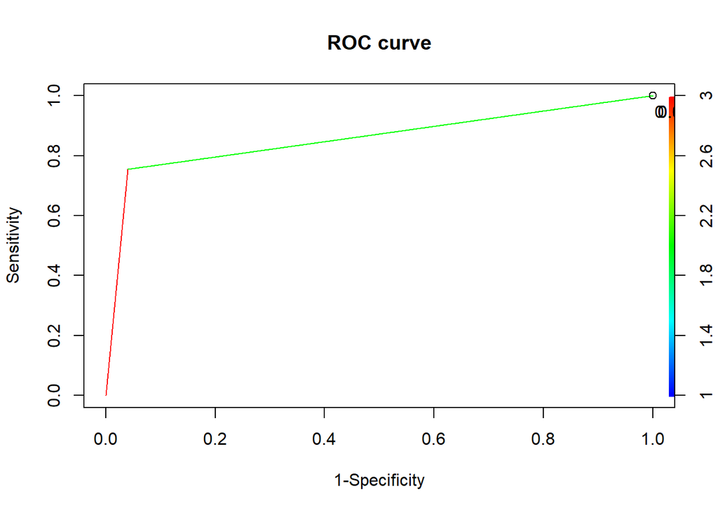

```r
# SVM ROC Curve
pred_svm = prediction(as.numeric(pred_svm_best_test), test2$Churn)
perf_svm = performance(pred_svm, "tpr", "fpr")

plot(perf_svm, colorize=T,
     main = "ROC curve",
     ylab = "Sensitivity",
     xlab = "1-Specificity",
     print.cutoffs.at=seq(0,1,0.3),
     text.adj= c(-0.2,1.7))
```

```r
# SVM AUC
auc_svm <- as.numeric(performance(pred_svm, "auc")@y.values)
auc_svm <- round(auc_svm, 3)
auc_svm
```

```
## [1] 0.857
```

Decision Tree - Gini index (default)

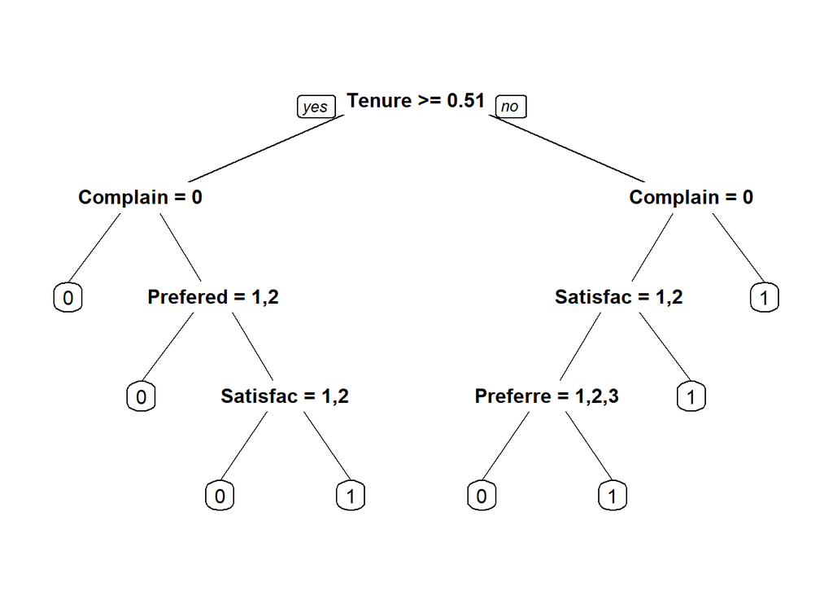

```r
# Building DT - Gini (default)
tree = rpart(data_balanced$Churn ~ ., data = data_balanced) # use data_balanced (non-normalized) dataset as DT is NOT influence by scales

# Plotting Tree
prp(tree)
```

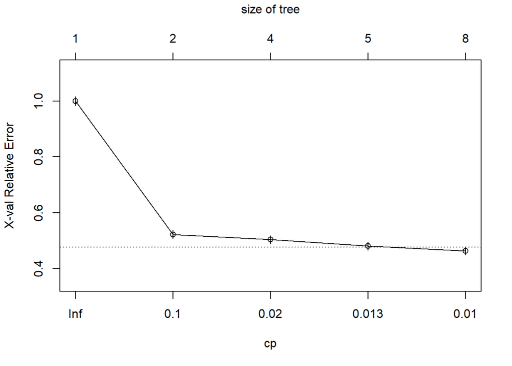

```r
plotcp(tree)
```

```r
summary(tree)
```

```
## Call:
## rpart(formula = data_balanced$Churn ~ ., data = data_balanced)
##   n= 3851
##
##           CP nsplit rel error    xerror       xstd
## 1 0.48877005      0 1.0000000 1.0000000 0.01658573
## 2 0.02219251      1 0.5112299 0.5224599 0.01443984
## 3 0.01764706      3 0.4668449 0.5037433 0.01426491
## 4 0.01016043      4 0.4491979 0.4807487 0.01403814
## 5 0.01000000      7 0.4187166 0.4636364 0.01386055
##
## Variable importance
##               Tenure     PreferedOrderCat             Complain
##                   50                   15                   11
##    SatisfactionScore       CashbackAmount    DaySinceLastOrder
##                    5                    5                    4
##        MaritalStatus PreferredPaymentMode      NumberOfAddress
##                    3                    3                    2
##             CityTier
##                    1
##
## Node number 1: 3851 observations,    complexity param=0.4887701
##   predicted class=0  expected loss=0.4855882  P(node) =1
##     class counts:  1981  1870
##    probabilities: 0.514 0.486
##   left son=2 (2249 obs) right son=3 (1602 obs)
##   Primary splits:
##       Tenure            < 0.5116074   to the right, improve=492.71170, (0 missing)
##       Complain          splits as  LR, improve=172.81820, (0 missing)
##       PreferedOrderCat  splits as  RLLRL, improve=153.96840, (0 missing)
##       MaritalStatus     splits as  LLR, improve= 97.68667, (0 missing)
##       DaySinceLastOrder < 0.3988324   to the right, improve= 94.89917, (0 missing)
##   Surrogate splits:
##       PreferedOrderCat  splits as  LLLRL, agree=0.669, adj=0.204, (0 split)
##       CashbackAmount    < 146.892     to the right, agree=0.623, adj=0.093, (0 split)
##       DaySinceLastOrder < 0.3506578   to the right, agree=0.613, adj=0.071, (0 split)
##       MaritalStatus     splits as  LLR, agree=0.609, adj=0.061, (0 split)
##       NumberOfAddress   < 0.4935279   to the right, agree=0.598, adj=0.033, (0 split)
##
## Node number 2: 2249 observations,    complexity param=0.02219251
```

[output cut: 128 more lines]

```
##
## Node number 23: 338 observations
##   predicted class=1  expected loss=0.3284024  P(node) =0.08776941
##     class counts:   111   227
##    probabilities: 0.328 0.672
##
## Node number 24: 133 observations
##   predicted class=0  expected loss=0.2857143  P(node) =0.03453648
##     class counts:    95    38
##    probabilities: 0.714 0.286
##
## Node number 25: 48 observations
##   predicted class=1  expected loss=0.1666667  P(node) =0.01246429
##     class counts:     8    40
##    probabilities: 0.167 0.833
```

DT Train & Test Validation (default)

```r
# Train prediction & confusion matrix
pred_tree_train = predict(tree, data_balanced, type = "class")

confusionMatrix(table(pred_tree_train, data_balanced$Churn), mode = "everything")
```

```
## Confusion Matrix and Statistics
##
##
## pred_tree_train    0    1
##               0 1621  423
##               1  360 1447
##
##                Accuracy : 0.7967
##                  95% CI : (0.7836, 0.8093)
##     No Information Rate : 0.5144
##     P-Value [Acc > NIR] : < 2e-16
##
##                   Kappa : 0.5926
##
##  Mcnemar's Test P-Value : 0.02671
##
##             Sensitivity : 0.8183
##             Specificity : 0.7738
##          Pos Pred Value : 0.7931
##          Neg Pred Value : 0.8008
##               Precision : 0.7931
##                  Recall : 0.8183
##                      F1 : 0.8055
##              Prevalence : 0.5144
##          Detection Rate : 0.4209
##    Detection Prevalence : 0.5308
##       Balanced Accuracy : 0.7960
##
##        'Positive' Class : 0
##
```

```r
# Test prediction & confusion matrix
pred_tree_test = predict(tree, test, type = "class")

confusionMatrix(table(pred_tree_test, test$Churn), mode = "everything")
```

```
## Confusion Matrix and Statistics
##
##
## pred_tree_test    0    1
##              0 1204   52
##              1  285  238
##
##                Accuracy : 0.8106
##                  95% CI : (0.7916, 0.8285)
##     No Information Rate : 0.837
##     P-Value [Acc > NIR] : 0.9986
##
##                   Kappa : 0.4755
##
##  Mcnemar's Test P-Value : <2e-16
##
##             Sensitivity : 0.8086
##             Specificity : 0.8207
##          Pos Pred Value : 0.9586
##          Neg Pred Value : 0.4551
##               Precision : 0.9586
##                  Recall : 0.8086
##                      F1 : 0.8772
##              Prevalence : 0.8370
##          Detection Rate : 0.6768
##    Detection Prevalence : 0.7060
##       Balanced Accuracy : 0.8146
##
##        'Positive' Class : 0
##
```

Pruning for DT

```r
# 10 fold - Cross Validation repeated 5 times
trctrl <- trainControl(method = "repeatedcv", number = 10, repeats = 5)
set.seed(3333)
dtree_fit <- train(Churn ~., data = data_balanced, method = "rpart",
                   trControl = trctrl,
                   tuneLength = 10,
                   metric = "Accuracy")


# To view output of cross validation
dtree_fit$results
```

```
##             cp  Accuracy     Kappa AccuracySD    KappaSD
## 1  0.002673797 0.8082616 0.6159983 0.02328529 0.04659750
## 2  0.003208556 0.8060801 0.6115812 0.02264643 0.04531864
## 3  0.003475936 0.8049372 0.6092768 0.02225014 0.04450788
## 4  0.003743316 0.8032225 0.6058321 0.02215930 0.04436777
## 5  0.004278075 0.8004180 0.6000894 0.02329091 0.04656105
## 6  0.005347594 0.7945494 0.5883990 0.02302270 0.04583043
## 7  0.005882353 0.7938740 0.5871079 0.02292999 0.04566220
## 8  0.007219251 0.7866039 0.5729890 0.02493443 0.04951915
## 9  0.016310160 0.7542429 0.5073457 0.02740052 0.05531722
## 10 0.488770053 0.6507012 0.2891165 0.10838108 0.22987269
```

Pruned DT - Gini

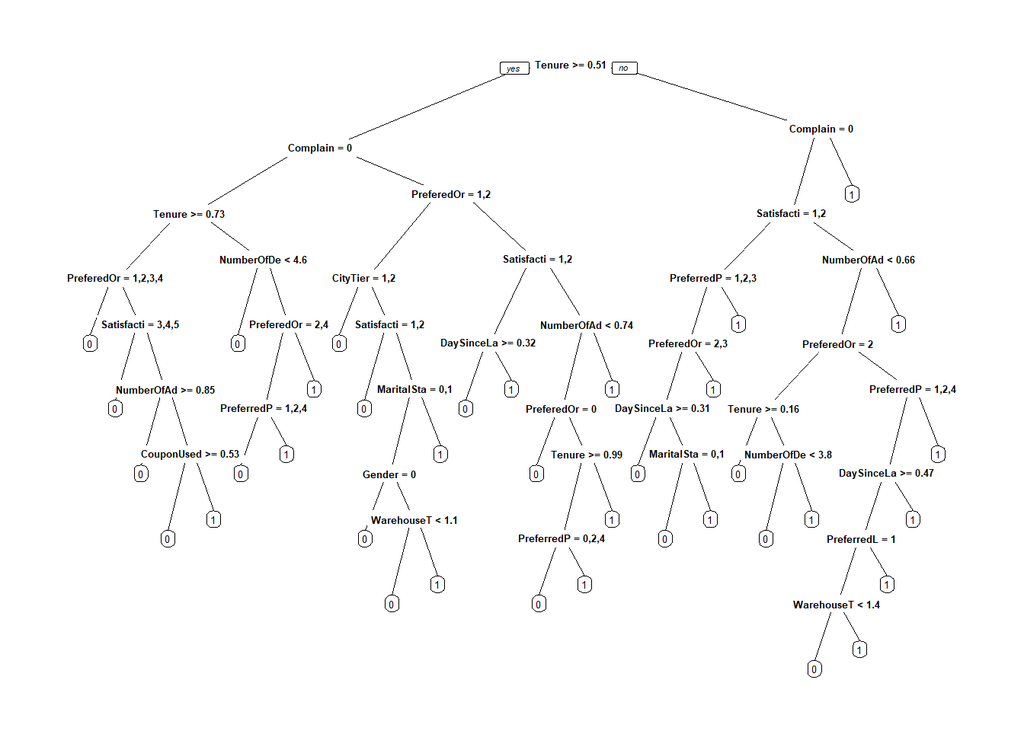

```r
# Building pruned tree
tree_prune = rpart(data_balanced$Churn ~ ., data = data_balanced, method = "class", cp = 0.0032)

# Plotting Pruned Trees
prp(tree_prune)
```

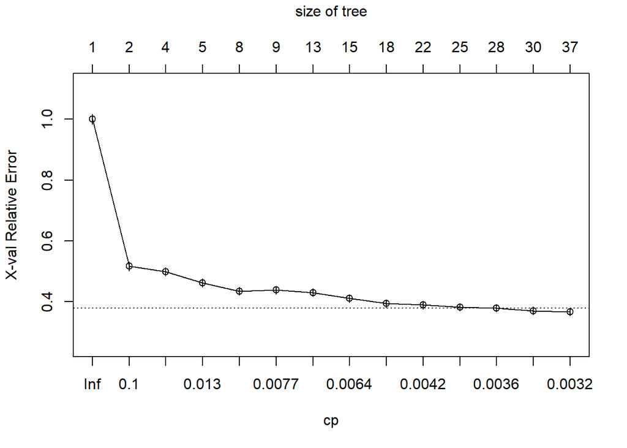

```r
plotcp(tree_prune)
```

```r
summary(tree_prune)
```

```
## Call:
## rpart(formula = data_balanced$Churn ~ ., data = data_balanced,
##     method = "class", cp = 0.0032)
##   n= 3851
##
##             CP nsplit rel error    xerror       xstd
## 1  0.488770053      0 1.0000000 1.0000000 0.01658573
## 2  0.022192513      1 0.5112299 0.5165775 0.01438577
## 3  0.017647059      3 0.4668449 0.4983957 0.01421336
## 4  0.010160428      4 0.4491979 0.4620321 0.01384351
## 5  0.008021390      7 0.4187166 0.4347594 0.01354287
## 6  0.007486631      8 0.4106952 0.4379679 0.01357933
## 7  0.006951872     12 0.3807487 0.4299465 0.01348764
## 8  0.005882353     14 0.3668449 0.4106952 0.01325986
## 9  0.004278075     17 0.3491979 0.3941176 0.01305463
## 10 0.004099822     21 0.3320856 0.3893048 0.01299342
## 11 0.003743316     24 0.3197861 0.3818182 0.01289668
## 12 0.003475936     27 0.3085561 0.3786096 0.01285466
## 13 0.003208556     29 0.3016043 0.3700535 0.01274088
## 14 0.003200000     36 0.2786096 0.3668449 0.01269757
##
## Variable importance
##                      Tenure            PreferedOrderCat
##                          34                          14
##                    Complain           SatisfactionScore
##                           7                           7
##              CashbackAmount           DaySinceLastOrder
##                           6                           5
##        PreferredPaymentMode             NumberOfAddress
##                           5                           4
##               MaritalStatus                    CityTier
##                           4                           3
##    NumberOfDeviceRegistered                  OrderCount
##                           3                           2
##             WarehouseToHome                  CouponUsed
##                           2                           1
##                      Gender OrderAmountHikeFromlastYear
##                           1                           1
##        PreferredLoginDevice              HourSpendOnApp
##                           1                           1
```

[output cut: 804 more lines]

```
##
## Node number 425: 30 observations
##   predicted class=1  expected loss=0.2  P(node) =0.007790184
##     class counts:     6    24
##    probabilities: 0.200 0.800
##
## Node number 848: 42 observations
##   predicted class=0  expected loss=0.1428571  P(node) =0.01090626
##     class counts:    36     6
##    probabilities: 0.857 0.143
##
## Node number 849: 13 observations
##   predicted class=1  expected loss=0.2307692  P(node) =0.003375747
##     class counts:     3    10
##    probabilities: 0.231 0.769
```

DT - Gini Train & Test Validation (pruned)

```r
# Train prediction & confusion matrix
pred_dt_train = predict(tree_prune, data_balanced, type = "class")

confusionMatrix(table(pred_dt_train, data_balanced$Churn), mode = "everything")
```

```
## Confusion Matrix and Statistics
##
##
## pred_dt_train    0    1
##             0 1727  267
##             1  254 1603
##
##                Accuracy : 0.8647
##                  95% CI : (0.8535, 0.8754)
##     No Information Rate : 0.5144
##     P-Value [Acc > NIR] : <2e-16
##
##                   Kappa : 0.7291
##
##  Mcnemar's Test P-Value : 0.5991
##
##             Sensitivity : 0.8718
##             Specificity : 0.8572
##          Pos Pred Value : 0.8661
##          Neg Pred Value : 0.8632
##               Precision : 0.8661
##                  Recall : 0.8718
##                      F1 : 0.8689
##              Prevalence : 0.5144
##          Detection Rate : 0.4485
##    Detection Prevalence : 0.5178
##       Balanced Accuracy : 0.8645
##
##        'Positive' Class : 0
##
```

```r
# Test prediction & confusion matrix
pred_dt_test = predict(tree_prune, test, type = "class")

confusionMatrix(table(pred_dt_test, test$Churn), mode = "everything")
```

```
## Confusion Matrix and Statistics
##
##
## pred_dt_test    0    1
##            0 1243   46
##            1  246  244
##
##                Accuracy : 0.8359
##                  95% CI : (0.8178, 0.8528)
##     No Information Rate : 0.837
##     P-Value [Acc > NIR] : 0.5665
##
##                   Kappa : 0.5292
##
##  Mcnemar's Test P-Value : <2e-16
##
##             Sensitivity : 0.8348
##             Specificity : 0.8414
##          Pos Pred Value : 0.9643
##          Neg Pred Value : 0.4980
##               Precision : 0.9643
##                  Recall : 0.8348
##                      F1 : 0.8949
##              Prevalence : 0.8370
##          Detection Rate : 0.6987
##    Detection Prevalence : 0.7246
##       Balanced Accuracy : 0.8381
##
##        'Positive' Class : 0
##
```

DT ROR Curve & AUC

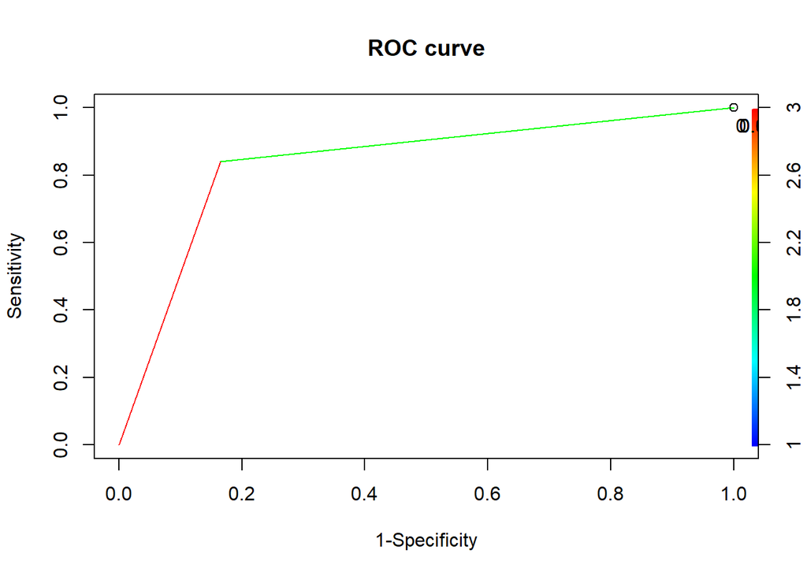

```r
# DT ROC Curve
pred_dt = prediction(as.numeric(pred_dt_test), test$Churn)
perf_dt = performance(pred_dt, "tpr", "fpr")

plot(perf_dt, colorize=T,
     main = "ROC curve",
     ylab = "Sensitivity",
     xlab = "1-Specificity",
     print.cutoffs.at=seq(0,1,0.3),
     text.adj= c(-0.2,1.7))
```

```r
# DT AUC
auc_dt <- as.numeric(performance(pred_dt, "auc")@y.values)
auc_dt <- round(auc_dt, 3)
auc_dt
```

```
## [1] 0.838
```